#### **To: Prof Green**

#### **From: Ralitza Mondal and CuiCui Lu**

#### **Date: 10/15/2019**

#### **RE: Real Estate Analysis**

# Introduction

We were provided a sample of 21,613 observations with 14 variables. We wanted to see what drives the prices of houses through the variables given to us.The continuous variables that we had we: sqft_living,sqft_lot,bathrooms,bedrooms,yr_built. The categorical variables were: waterfront,view,condition,yr_renovated,zip_code,floors,grade. It is important to analyze these variables thoroughly so that we can answer When,What and Why some of these variable if not all drive the prices for houses.

We found that the median price was the best indicator since the price was skewed.Moreover through correlation test, we found out that there is a strong positive correlation between sqft_living and price. However, because of random nature of sft_lot, it did not give us much useful information.Below we have a clear presentation of median price with sqft_living.

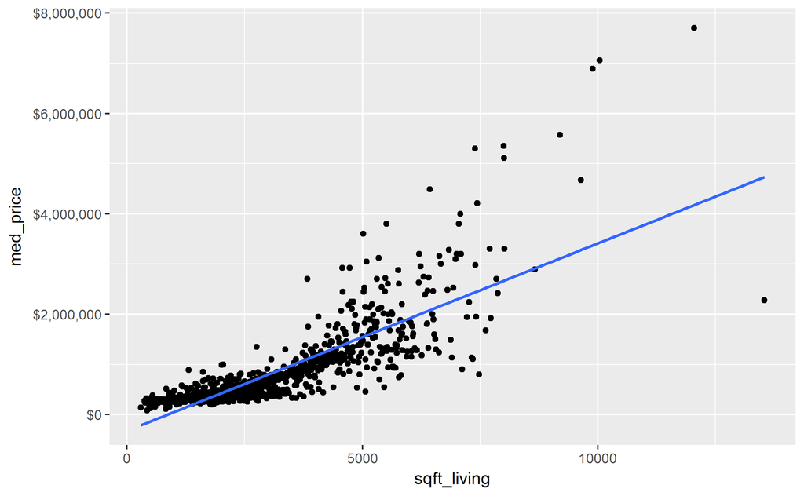

# Finding Number 1

We started our investigation with when from our 3 Ws(when,what,why). When did the price vary throughout the years and if there is a something unusual in the pattern. Our findings is below:

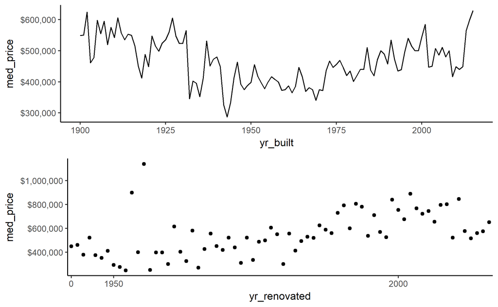

# Finding Number 2

After analyzing the median prices throughout the years, we decided to what variables could be cause behind. Grade and condition were chosen first because positive correlation with price.

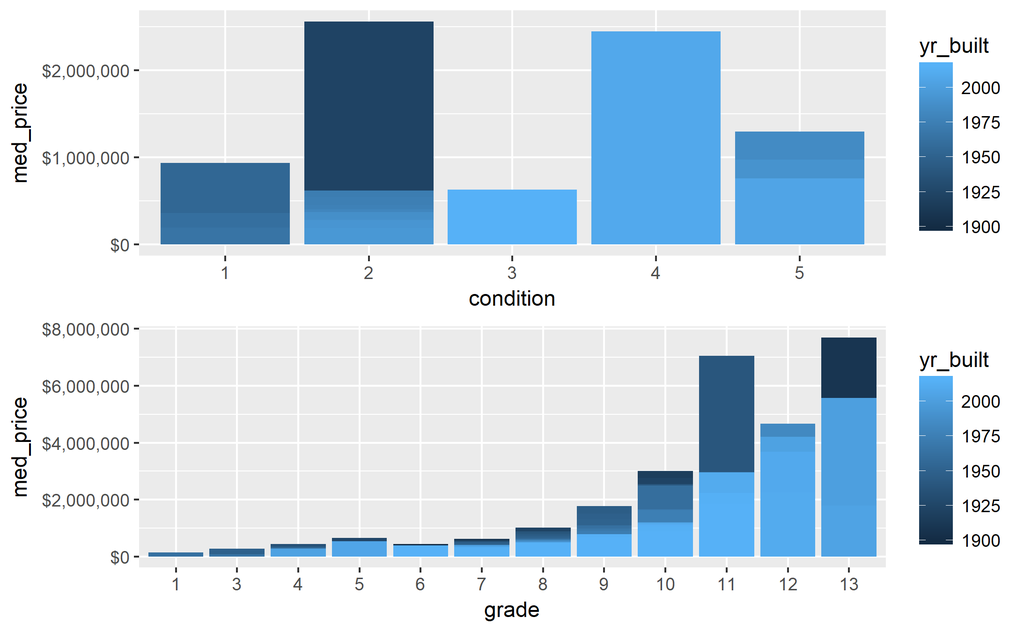

This leads us to our last finding, which of the two, condition or grade is better at telling the story? and why?

# Finding Number 3

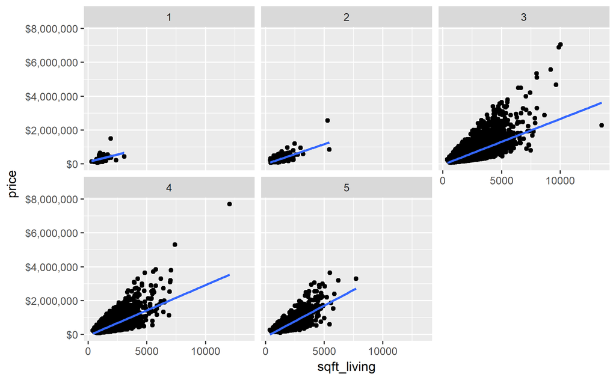

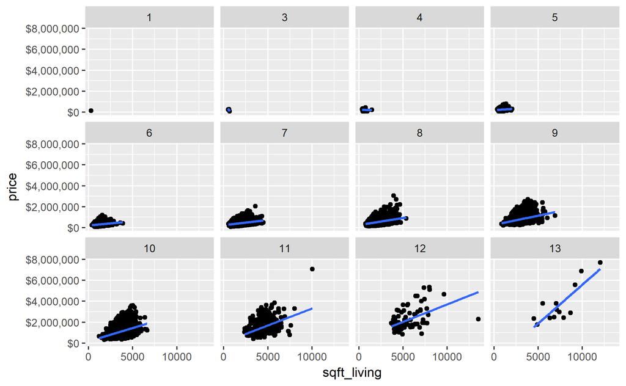

# Conclusion

The summary to take away is price has strong positive correlation with sqft_living condition is a good predictor of price and older houses had higher grades,higher median prices,but have low condition scores.This was just a slice of the analysis that determines the prices for houses in the market. We can look further into whether bathroom/floor or bedrooms make the median price substantially differ. This will further answer questions the fall and rise in median prices throughout the years.We can also dive deeperinto the categorical analysis of the conditions and grading for extra features like view and waterfront.But for now, we will leave our quick analysis here. We will be happy to dicuss more with you.

Sincerely, Ralitza and CuiCui